# STA 101 - HW 5

Mingyi Xue

May 18, 2018

### Load databases into current workingspace:

```r
control <- read.csv("~/STA 101/Homework/HW5/control.csv")
flu <- read.csv("~/STA 101/Homework/HW5/flu.csv")
rat <- read.csv("~/STA 101/Homework/HW5/rat.csv")
```

### Install and load packages:

```r
library(ggplot2)
library(pROC)
library(nnet)
library(LogisticDx)
library(asbio)
```

### Problem 1

**(a)**

```
## Start:  AIC=136.94
## shot ~ 1
##
##          Df Deviance    AIC
## + aware   1   113.20 117.20
## + age     1   116.27 120.27
## + gender  1   132.88 136.88
## <none>        134.94 136.94
##
## Step:  AIC=117.2
## shot ~ aware
##
##          Df Deviance    AIC
## + age     1   105.80 111.80
## + gender  1   111.19 117.19
## <none>        113.20 117.20
##
## Step:  AIC=111.8
## shot ~ aware + age
##
##          Df Deviance    AIC
## <none>        105.80 111.80
## + gender  1   105.09 113.09
```

Final model:

```
## shot ~ aware + age
```

**(b)**

```
## Start:  AIC=113.09
## shot ~ age + aware + gender
##
##          Df Deviance    AIC
## - gender  1   105.80 111.80
## <none>        105.09 113.09
## - age     1   111.19 117.19
## - aware   1   115.80 121.80
##
## Step:  AIC=111.8
## shot ~ age + aware
##
##         Df Deviance    AIC
## <none>       105.80 111.80
## - age    1   113.20 117.20
## - aware  1   116.27 120.27
```

Final Model:

```
## shot ~ age + aware
```

**(c)**

```
##
## Call:  glm(formula = shot ~ aware + age, family = binomial(link = logit),
##     data = flu)
##
## Coefficients:
## (Intercept)        aware          age
##    -1.45778     -0.09547      0.07787
##
## Degrees of Freedom: 158 Total (i.e. Null);  156 Residual
## Null Deviance:       134.9
## Residual Deviance: 105.8     AIC: 111.8
```

```
## 'log Lik.' -52.8977 (df=3)
```

The logistic regression model is $ln\frac{\hat\pi}{1-\hat\pi}=-1.4578+0.0779X_{1} -0.0955 X_{2}$.  
The log-likelihood of the model is -52.8977.

**(d)**

```
##
## Call:  glm(formula = shot ~ aware + age + aware * age, family = binomial(link = logit),
##     data = flu)
##
## Coefficients:
## (Intercept)        aware          age    aware:age
##   1.2378112   -0.1455268    0.0377140    0.0007486
##
## Degrees of Freedom: 158 Total (i.e. Null);  155 Residual
## Null Deviance:       134.9
## Residual Deviance: 105.8     AIC: 113.8
```

```
## 'log Lik.' -52.8752 (df=4)
```

The log-likelihood of the model is -52.8752.

**(e)**

```
##
## Call:  glm(formula = shot ~ aware + age + aware * age, family = binomial(link = logit),
##     data = flu)
##
## Coefficients:
## (Intercept)        aware          age    aware:age
##   1.2378112   -0.1455268    0.0377140    0.0007486
##
## Degrees of Freedom: 158 Total (i.e. Null);  155 Residual
## Null Deviance:       134.9
## Residual Deviance: 105.8     AIC: 113.8
```

```
##
## Call:  glm(formula = shot ~ aware + age, family = binomial(link = logit),
##     data = flu)
##
## Coefficients:
## (Intercept)        aware          age
##    -1.45778     -0.09547      0.07787
##
## Degrees of Freedom: 158 Total (i.e. Null);  156 Residual
## Null Deviance:       134.9
## Residual Deviance: 105.8     AIC: 111.8
```

```
## 'log Lik.' 0.1680719 (df=3)
```

$H_{0}$:$\hat\beta_{3} = 0$.  
$H_{A}$:$\hat\beta_{3} \neq 0$.  
The test statistics LR equals 0.045, p-value equals 0.1681.

**(f)**

p-value equals 0.1681 > $\alpha = 0.05$ and is large enough for us to fail to reject $H_{0}$, so we can conclude that the interaction term should be dropped.

### Problem 2

**(a)**

```
## (Intercept)   exp.aware     exp.age
##   0.2327517   0.9089435   1.0809847
```

Holding all other variables as constant, when age increases by 1 year, the odds of flu shot will be 1.081 times that of what it was.

**(b)**

Holding all other variables as constant, when health awareness score increases by 1 point, the odds of flu shot will be 0.9089 times that of what it was.

**(c)**

```
##         1
## 0.1427452
```

**(d)**

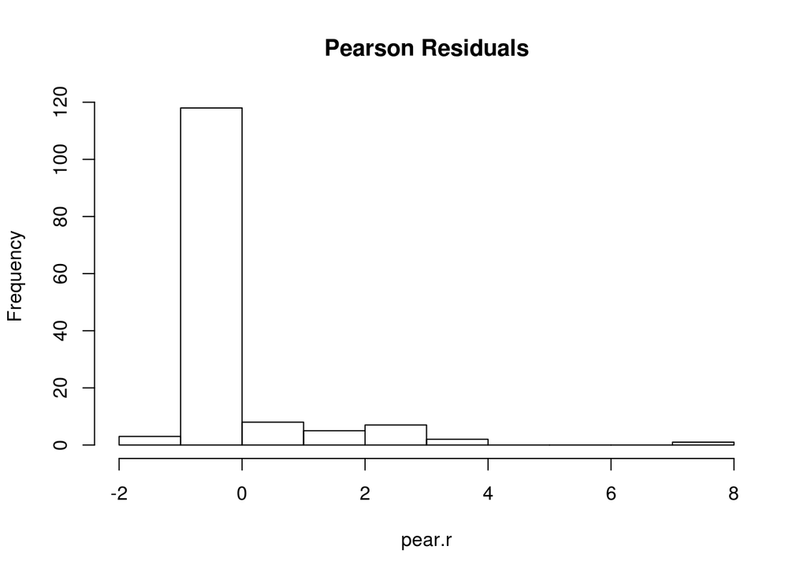

There exist values above 4.

```
##    (Intercept) aware age y          P n       yhat       Pr       dr
## 1:           1    75  59 1 0.01757171 1 0.01757171 7.477275 2.843049
##              h      sPr      sdr   dChisq     dDev    dBhat
## 1: 0.009214369 7.511965 2.856239 56.42961 8.158102 0.524799
```

**(e)**

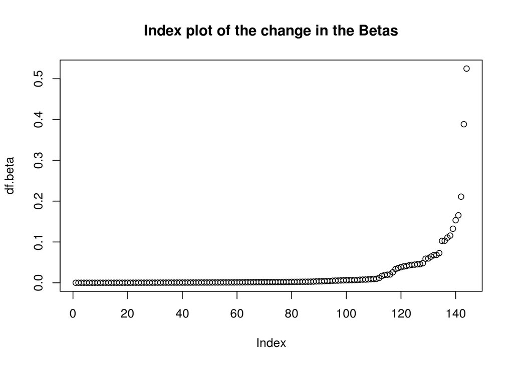

There exist values above 0.3.

```
##    (Intercept) aware age y          P n       yhat       Pr       dr
## 1:           1    42  51 1 0.18300345 1 0.18300345 2.112907 1.842960
## 2:           1    75  59 1 0.01757171 1 0.01757171 7.477275 2.843049
##              h      sPr      sdr    dChisq     dDev     dBhat
## 1: 0.074538023 2.196348 1.915740  4.823945 3.670059 0.3885274
## 2: 0.009214369 7.511965 2.856239 56.429612 8.158102 0.5247990
```

### Problem 3

**(a)**

```
## trying + age
## trying + edu
## trying + working
## trying + age
## trying + working
## trying + working
```

Final model:  
con ~ edu + age

```
## Call:
## multinom(formula = con ~ edu + age, data = control, trace = FALSE)
##
## Coefficients:
##       (Intercept)       eduG        eduL       eduM        age
## None    -1.031659 -0.6054868  -0.1114698 -0.3608938 0.05140516
## Short   -3.683428  0.4272499 -10.6328484 -2.2720652 0.10534161
##
## Std. Errors:
##       (Intercept)      eduG         eduL      eduM        age
## None    0.6105538 0.3536421 5.034946e-01 0.3711520 0.01808688
## Short   0.8114100 0.4010035 5.862023e-05 0.8087724 0.02234756
##
## Residual Deviance: 557.497
## AIC: 577.497
```

**(b)**

```
## trying - age
## trying - edu
## trying - working
## trying - age
## trying - edu
```

Final Model:  
con ~ age + edu

```
## Call:
## multinom(formula = con ~ age + edu, data = control, trace = FALSE)
##
## Coefficients:
##       (Intercept)        age       eduG        eduL       eduM
## None    -1.031659 0.05140516 -0.6054868  -0.1114698 -0.3608938
## Short   -3.683428 0.10534161  0.4272499 -10.6328484 -2.2720652
##
## Std. Errors:
##       (Intercept)        age      eduG         eduL      eduM
## None    0.6105538 0.01808688 0.3536421 5.034946e-01 0.3711520
## Short   0.8114100 0.02234756 0.4010035 5.862023e-05 0.8087724
##
## Residual Deviance: 557.497
## AIC: 577.497
```

**(c)**

```
## Call:
## multinom(formula = con ~ edu + age, data = control, trace = FALSE)
##
## Coefficients:
##       (Intercept)       eduG        eduL       eduM        age
## None    -1.031659 -0.6054868  -0.1114698 -0.3608938 0.05140516
## Short   -3.683428  0.4272499 -10.6328484 -2.2720652 0.10534161
##
## Residual Deviance: 557.497
## AIC: 577.497
```

$ln\frac{\hat\pi_{None}}{\hat\pi_{Long}} = -1.0317-0.6055X_{eduG} -0.1115X_{eduL} -0.3609X_{eduM} +0.0514X_{age}$

$ln\frac{\hat\pi_{Short}}{\hat\pi_{Long}} = -3.6834+0.4272X_{eduG} -10.6328X_{eduL} -2.2721X_{eduM} +0.1053X_{age}$

**(d)**

When age increases by 1 year, the relative probability of no birth control compared to long term birth control is 1.0527 times what it was, holding level of education constant.

**(e)**

When age increases by 1 year, the relative probability of short birth control compared to long term birth control is 1.1111 times what it was, holding level of education constant.

### Problem 4

**(a)**

**(b)**

**(c)**

```
##                        LL  K D.F.     AIC      BIC
## con ~ age       -306.9340  4  296 621.868 636.6832
## con ~ age + edu -278.7485 10  290 577.497 614.5349
```

```
## [1] 2.449116e-10
```

$H_{0}$:$\hat\beta_{2}=\hat\beta_{3}=\hat\beta_{4}=0$.  
$H_{A}$:Not all $\hat\beta_{i} = 0$, where i=2,3,4.  
The test statistics LR equals 56.371, p-value equals 2.449115810^{-10}.

**(d)**

p-value equals 2.449115810^{-10} < $\alpha = 0.10$ and is small enough for us to reject $H_{0}$ and conclude that $X_{2}$ cannot be dropped from the model.

**(e)**

```
##      Long      None     Short
## 0.3729248 0.3221381 0.3049371
```

### Problem 5

**(a)**

```
## [1] "Long"  "None"  "Short"
```

```
##
## Call:  glm(formula = con ~ edu + age, family = binomial(logit), data = AvsLS)
##
## Coefficients:
## (Intercept)         eduG         eduL         eduM          age
##     -3.7968       0.4583     -17.4359      -1.9400       0.1064
##
## Degrees of Freedom: 168 Total (i.e. Null);  164 Residual
## Null Deviance:       229.3
## Residual Deviance: 172.1     AIC: 182.1
```

Logistic regression model: $ln\frac{\hat\pi}{1-\hat\pi}=-3.7968 + 0.4583X_{eduG}-17.4359X_{eduL}-1.94X_{eduM}+0.1064X_{age}$

**(b)**

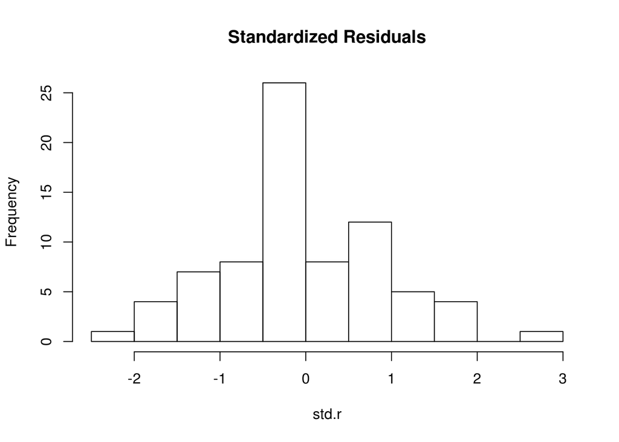

```
## Empty data.table (0 rows) of 17 cols: (Intercept),eduG,eduL,eduM,age,y...
```

There is no observations larger than 3 or smaller than -3.

**(c)**

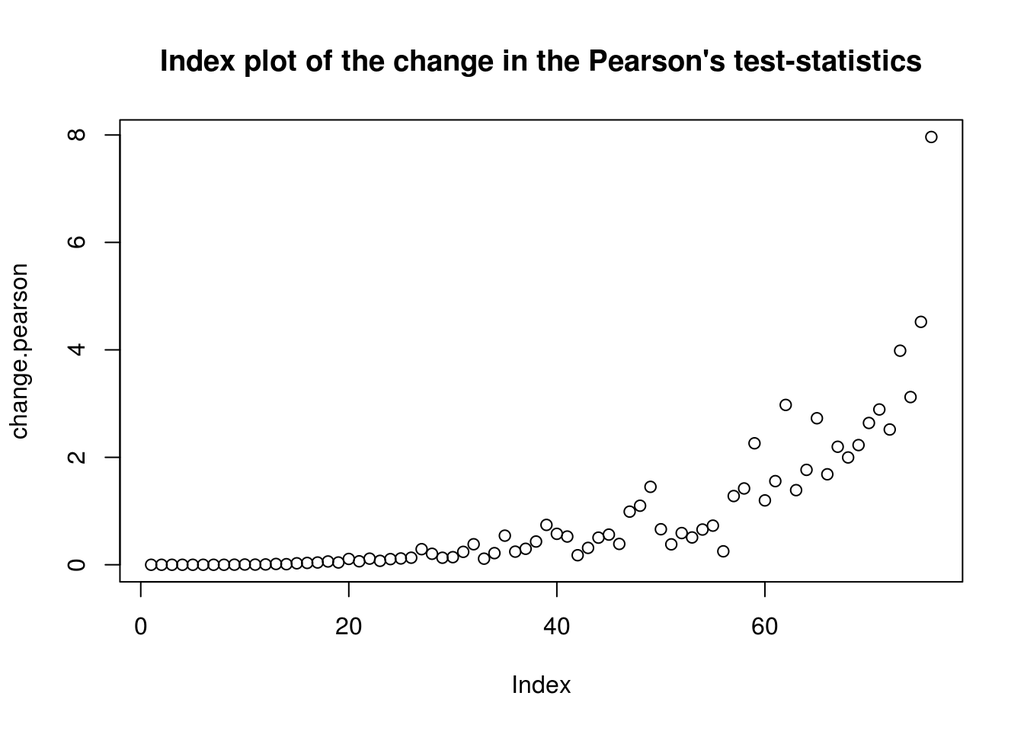

```
## Empty data.table (0 rows) of 17 cols: (Intercept),eduG,eduL,eduM,age,y...
```

There is no observations larger than 8.

**(d)**

Since there is no outliers in standardized residuals and $\Delta\chi^{2}$, no observations should be removed.

### Problem 6

**(a)**

False. An outlier is always an influential point, but an influential point is not necessarily an outlier. It may be repeated rows in the dataset.

**(b)**

False. $e^{\beta_{i}}$ for different categories are usually different.

**(c)**

False. If we reject $H_{0}$, we can conclude that the larger model is better.

**(d)**

False. Usually, a cutoff is $\pm 3$ for standardized residuals.

### Problem 7

**(a)**

```
##                Beef  Cereal    Pork
## Means       89.6000 84.9000 89.1000
## Std. Dev    17.7123 14.9944 17.3202
## Sample size 20.0000 20.0000 20.0000
```

**(b)**

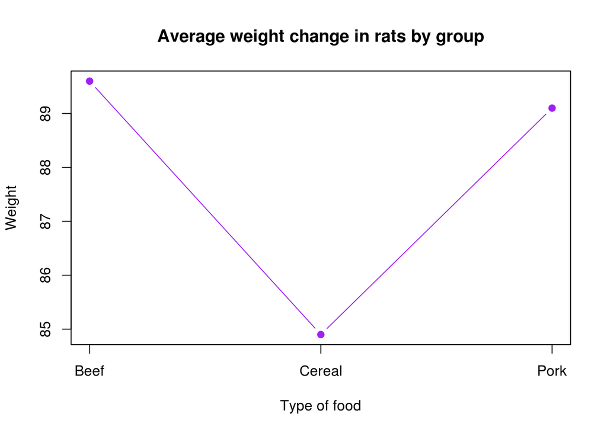

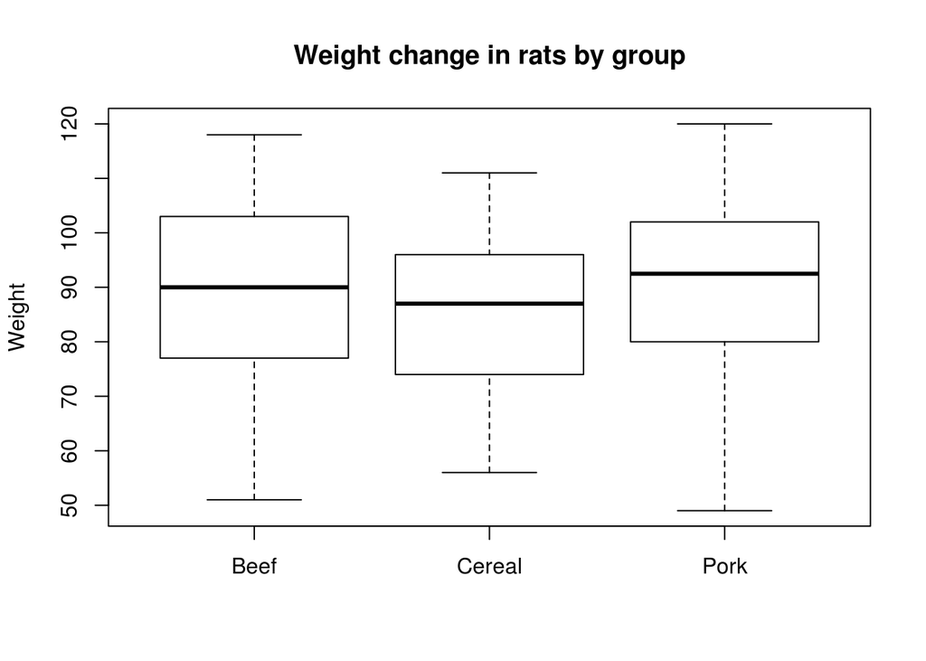

There appears to be a difference between group Cereal and other groups.

**(c)**

Hypothesis:  
$H_{0}$: Smaller model fits better.  
$H_{A}$: Largerer model fits better.  
Test statistics:  
$F_{s}=\frac{SSE_{s}-SSE_{L}}{dof(SSE_{s}-dof(SSE_{L}))}/\frac{SSE_{L}}{dof(SSE_{L})}$

**(d)**

```
## Analysis of Variance Table
##
## Model 1: Weight ~ 1
## Model 2: Weight ~ Type
##   Res.Df   RSS Df Sum of Sq      F Pr(>F)
## 1     59 16199
## 2     57 15932  2    266.53 0.4768 0.6232
```

Test-statistic equals 0.4768.  
P-value equals 0.6232.

**(e)**

P-value = 0.6232 > $\alpha = 0.10$ is large enough for us to fail to reject $H_{0}$, and conclude that smaller model is better. Means in different groups tend to be equal.

### Problem 8

**(a)**

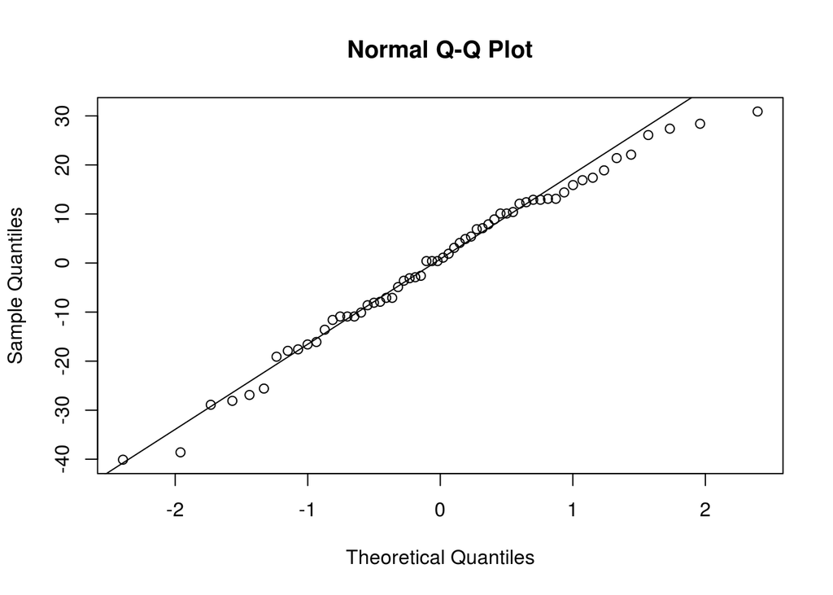

According to qqplot, the data appears to be approximately normal.

**(b)**

```
##
##  Shapiro-Wilk normality test
##
## data:  the.model$residuals
## W = 0.98194, p-value = 0.516
```

Hypothesis:  
$H_{0}$: The data is normally distributed.  
$H_{A}$: The data is not normally distributed.  
P-value of S-W test equals 0.516 > $\alpha = 0.05$. It is large for us to fail to reject $H_{0}$ and conclude that the data is normally distributed.

**(c)**

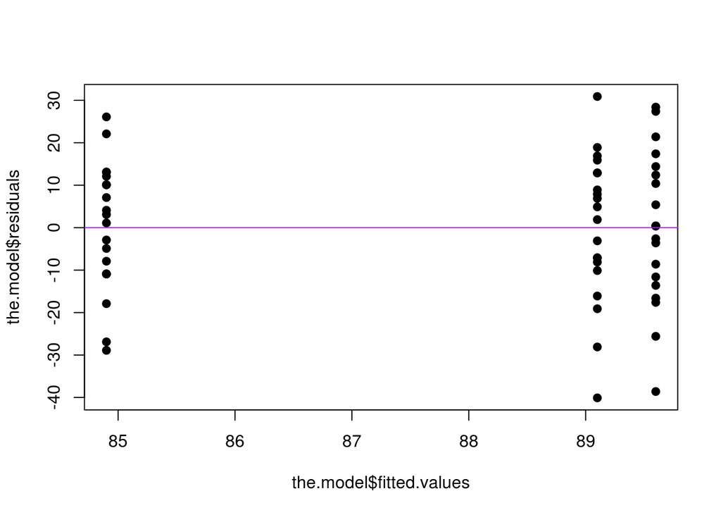

According to the plot, there appears to be constant variance.

**(d)**

```
##
## Modified Levene's test of homogeneity of variances
##
## df1 = 2,  df2 = 57,  F = 0.17997,  p-value = 0.83577
```

Since the p-value equals 0.8358 > $\alpha = 0.05$. It is large enough for us to fail to reject $H_{0}$ and conclude that there is no evidence for non-constant variance between groups.

**(e)**

The assumptions of ANOVA are met in this problem, considering all criteria tested above.

### R Appendix

```r
control <- read.csv("~/STA 101/Homework/HW5/control.csv")
flu <- read.csv("~/STA 101/Homework/HW5/flu.csv")
rat <- read.csv("~/STA 101/Homework/HW5/rat.csv")
library(ggplot2)
library(pROC)
library(nnet)
library(LogisticDx)
library(asbio)
empty.model = glm(shot~1, data = flu, family = binomial(link = logit))
full.model = glm(shot~., data = flu, family = binomial(link = logit))
best.forward = step(empty.model,scope = list(lower = empty.model, upper = full.model), direction = "forward", criterion = "AIC")
best.forward$formula
best.backward= step(full.model,scope = list(lower = empty.model, upper = full.model), direction = "backward", criterion = "AIC")
best.backward$formula
final.model = glm(shot~aware + age, data = flu, family = binomial(link = logit))
final.coef = final.model$coefficients
final.model
LL = logLik(final.model)
round(LL, 4)
final.iteraction = glm(shot~aware + age + aware*age, data = flu, family = binomial(link = logit))
final.iteraction
LL.iteraction = logLik(final.iteraction)
round(LL.iteraction, 4)
model.A = final.iteraction
model.A
model.0 = final.model
model.0
LLA = logLik(model.A)
LL0 = logLik(model.0)
pA = length(model.A$coefficients)
p0 = length(model.0$coefficients)
LR = -2*(LL0 - LLA)
p.value = pchisq(LR, df = pA - p0)
p.value

exp.betas = exp(final.model$coefficients)
names(exp.betas) = c("(Intercept)",  "exp.aware", "exp.age")
exp.betas

x.star = data.frame(age = 57, aware = 50, gender = "M")
the.predict = predict(final.model, x.star, type = "response")
the.predict
good.stuff = dx(final.model)
pear.r = good.stuff$Pr
std.r = good.stuff$sPr
df.beta = good.stuff$dBhat
change.pearson = good.stuff$dChisq
hist(pear.r, main="Pearson Residuals")
good.stuff[pear.r > 4]
plot(df.beta, main="Index plot of the change in the Betas")
good.stuff[df.beta >0.3]
empty.model = multinom(con~1, data = control, trace = FALSE)
full.model = multinom(con~., data = control, trace = FALSE)
best.forward = step(empty.model,scope = list(lower = empty.model, upper = full.model), direction = "forward", criterion = "AIC", trace = FALSE)
summary(best.forward)
best.backward= step(full.model,scope = list(lower = empty.model, upper = full.model), direction = "backward", criterion = "AIC", trace = FALSE)
summary(best.backward)
final.model = multinom(con ~ edu + age, data = control, trace = FALSE)
final.model
final.coef = coef(final.model)




GOF.Multi = function(the.model){
  num.para = the.model$edf
  n = nrow(the.model$residuals)
  LL = logLik(the.model)
  df.model = n - num.para
  AIC = -2*logLik(the.model) +2*the.model$edf
  BIC = -2*logLik(the.model) +log(n)*the.model$edf
  the.results = c(LL,num.para,df.model,AIC,BIC)
  names(the.results) = c("LL","K","D.F.","AIC","BIC")
  return(the.results)
}
model.list = c("con ~ age","con ~ age + edu")
model.fits = lapply(model.list,function(the.form){
  multinom(the.form,data = control,trace = FALSE)
})
all.GOF = t(sapply(model.fits,function(models){
  GOF.Multi(models)
}))
rownames(all.GOF) = model.list
round(all.GOF,digits = 4)
LL0 = all.GOF[1,"LL"]
LLA = all.GOF[2,"LL"]
p0 = all.GOF[1,"K"]
pA = all.GOF[2,"K"]
LR = -2*(LL0 - LLA)
p.value = pchisq(LR, pA-p0, lower.tail = FALSE)
p.value
# model.0 = multinom(con ~ age, data = control, trace = FALSE)
# model.A = multinom(con ~ age + edu, data = control, trace = FALSE)
# LLA = logLik(model.A)
# LL0 = logLik(model.0)
# pA = model.A$edf
# p0 = model.0$edf
# LR = -2*(LL0 - LLA)
# p.value = pchisq(LR, pA-p0, lower.tail = FALSE)
# p.value

x.star = data.frame(age = 29, edu = "G", working = "Y")
predict(final.model, x.star,type = "probs")
split.data = split(control, control$con)
names(split.data)
AvsLS=rbind(split.data[[1]], split.data[[3]])
model.AvsLS = glm(con~ edu + age, data = AvsLS, family = binomial(logit))
model.AvsLS
the.coef = model.AvsLS$coefficients
good.stuff = dx(model.AvsLS)
pear.r = good.stuff$Pr
std.r = good.stuff$sPr
df.beta = good.stuff$dBhat
change.pearson = good.stuff$dChisq
hist(std.r, main="Standardized Residuals")
good.stuff[std.r > 3 | std.r< -3]
plot(change.pearson, main="Index plot of the change in the Pearson's test-statistics")
good.stuff[change.pearson > 8]





group.means = by(rat$Weight, rat$Type, mean)
group.sds = by(rat$Weight, rat$Type, sd)
group.nis = by(rat$Weight, rat$Type, length)
the.summary=rbind(group.means, group.sds, group.nis)
the.summary = round(the.summary,digits=4)
colnames(the.summary) = names(group.means)
rownames(the.summary) = c("Means","Std. Dev","Sample size")
the.summary
plot(group.means,xaxt="n",pch=19,col="purple",xlab = "Type of food", ylab="Weight",main="Average weight change in rats by group", type="b")
axis(1,1:length(group.means),names(group.means))
boxplot(rat$Weight~rat$Type,main="Weight change in rats by group",ylab="Weight")

larger.model=lm(Weight~Type,data = rat)
smaller.model=lm(Weight~1,data = rat)
anova.table=anova(smaller.model, larger.model)
anova.table

the.model = larger.model
qqnorm(the.model$residuals)
qqline(the.model$residuals)
sw.test = shapiro.test(the.model$residuals)
sw.test
plot(the.model$fitted.values,the.model$residuals, pch=19)
abline(h=0,col="purple")
ML.test = modlevene.test(the.model$residuals, rat$Type)
ML.test
```